# Hw2

## Problem 5

A graphical technique for checking whether a sample has an approximate normal distribution is a “quantile- quantile” plot. The R command is qqnorm(x), where x is the vector of sample values. If the plot is approximately a straight line, then this suggests that the sample comes from a normal distribution. Use the dataset from the openintro package to find out which of the the four distributions (three exams and course grade) is the closest to a normal distribution? You can load the dataset with the following commands library(openintro) and data(exam_grades). Explore this by making qqnorm() and qqline() plots of the four distributions. How close to straight lines are the plots in each case? How do the plots differ from straight lines? Hint: Make sure to remove the NA values.

```r
library(openintro)
```

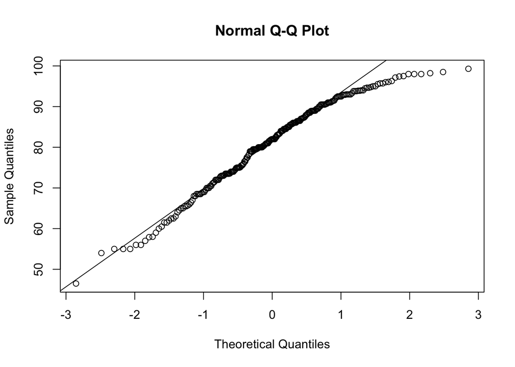

```r
data("exam_grades")
exam_grades <- exam_grades %>% drop_na()
ex1 <- exam_grades$exam1
ex2 <- exam_grades$exam2
ex3 <- exam_grades$exam3
courseGrade <- exam_grades$course_grade

# exam grades 1
qqnorm(ex1)
qqline(ex1)
```

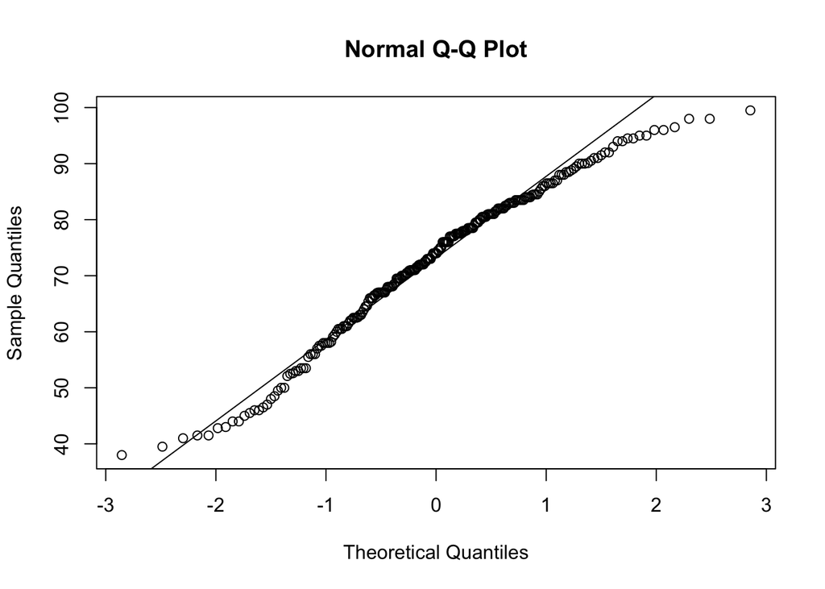

```r
# exam grades 2
qqnorm(ex2)
qqline(ex2)
```

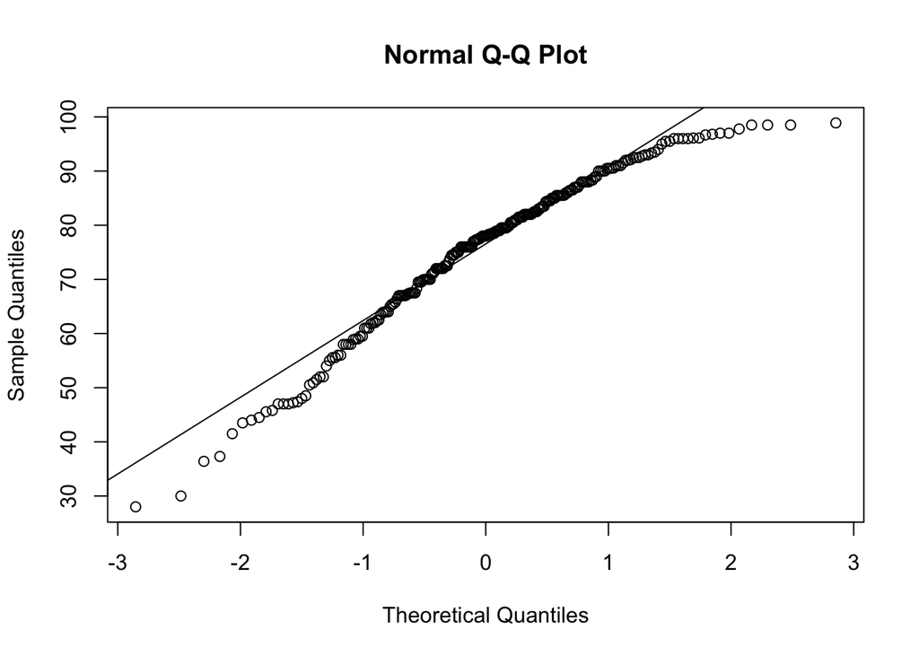

```r
# exam grades 3
qqnorm(ex3)
qqline(ex3)
```

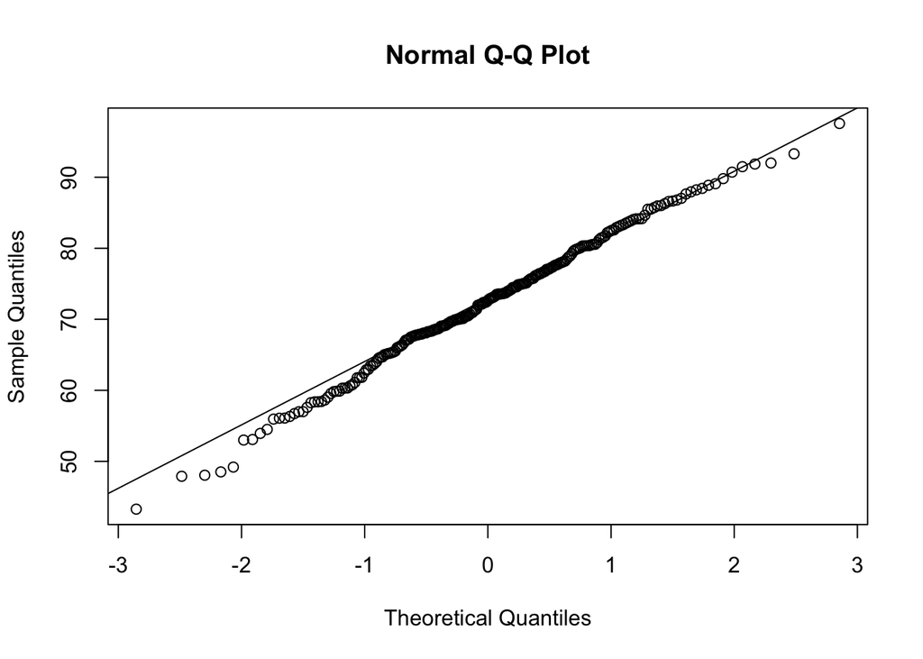

```r
# course grade
qqnorm(courseGrade)
qqline(courseGrade)
```

## Problem 6

If X has a continuous distribution with cumulative distribution function F, then the new random variable U = F(X) has a uniform U(0,1) distribution. Verify this with simulations for three different continuous distributions of your choice, by making a random sample of sufficient size, sorting it, plugging it into the cdf F, and plotting the result.

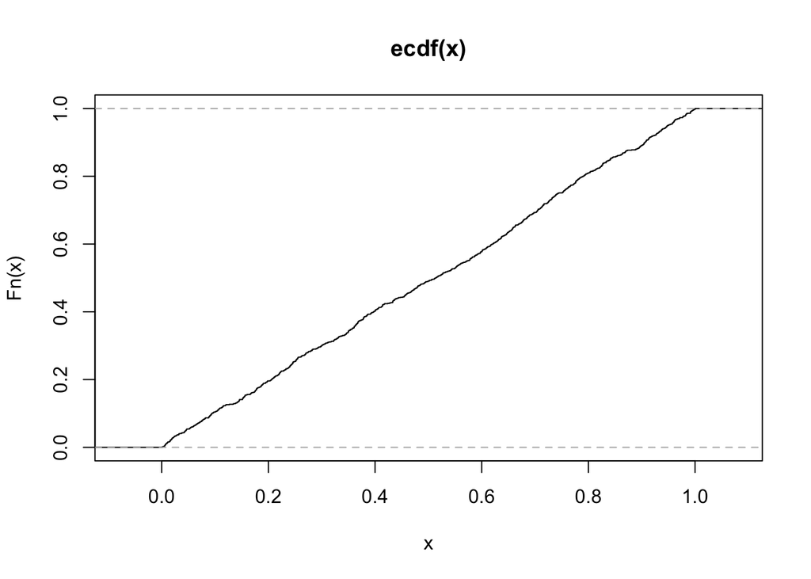

```r
# exponential
vals <- rexp(1000,1)
probs <- pexp(vals,1)
plot.ecdf(probs)
```

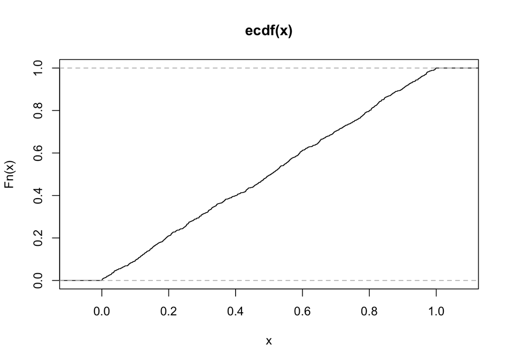

```r
# normal
vals <- rnorm(1000)
probs <- pnorm(vals)
plot.ecdf(probs)
```

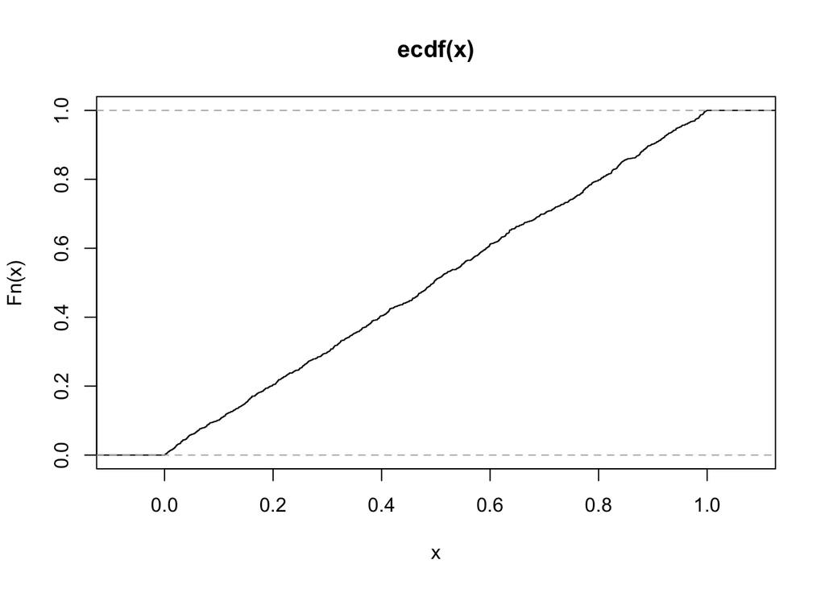

```r
# Cauchy
vals <- rcauchy(1000)
probs <- pcauchy(vals)
plot.ecdf(probs)
```

### Observations

All three graphs have a straight, diagonal line on the ecdf, so we can be sure that the distributions are uniform.

## Bonus Question

Suppose for X = X1 +X2 is the sum of two exponentially distributed random variables with the same param- eter λ. Then Xα is very nearly normally distributed for a suitable choice of α. Determine an approximate value for α (within 0.05), using a simulation and qqnorm() plots for each of your choices of α.

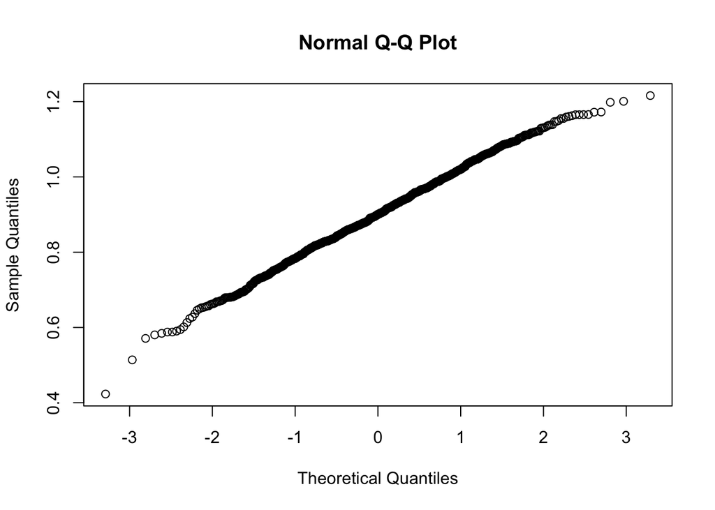

```r
vals <- rgamma(1000,2,3) # sum of two exponential random variables is a gamma distribution
p <- 0.01 # probability
a <- 0.1 # alpha value
while(p <= 0.05){ # loop through values of p up to 0.05
  x <- vals^a # raise to the power of alpha
  p <- shapiro.test(x)[2] # check normality
  a <- a + 0.01 # increase alpha
}
qqnorm(x) # see normality distribution
```